# EPID 8130 Project Analysis

Zane

11/27/2021

# Introduction

For my final project for EPID 8130, I conducted a systematic review of norovirus challenge studies. After the standard systematic review steps, I then removed studies which contained unusable data as well as studies that referenced previously-completed challenge cohorts. In this document I will conduct a meta-analysis of the proportion of challenge participents who were infected, and examine influences of the summary measure.

First, I will load necessary packages–I think it is best practice to always do this at the top of the script. I’ll also load the data and set the theme for the forest plots here.

```r
# Load packages
library(here)
library(dplyr)
```

```r
library(ggplot2)
library(meta)
library(metafor)
library(dmetar)
library(magick)
library(robvis)
library(zlib)
library(janitor)
# Read in the data
dat <- read.csv(here::here("data", "abstracted-data.csv")) %>%
  janitor::clean_names() %>%
  mutate(study = paste(first_author, year_published))

# Change forest plot formatting
zlib::quiet(settings.meta("jama"))

save_base_plot <- function(.data, pth, FUN = plot,
                           w = 3200, h = 1800, r = 300, ...) {
  # Create graphics device
  png(file = pth, width = w, height = h, res = r)
  # Actually generate forest plot
  FUN(.data, ...)
  # Turn off graphics device (quietly)
  zlib::quiet(dev.off())
  # Trim whitespace
  magick::image_read(pth) |>
    magick::image_trim() |>
    magick::image_write(path = pth)
}

# Set ggplot theme
theme_set(theme_bw() + theme(axis.text = element_text(color = "black")))
```

# Proportion infected

In the data we have two potential outcomes–the proportion of challenge participents who had confirmed norovirus infection, and the proportion who displayed clinical illness (acute gastroenteritis). For a few of the older studies, infection was only measured with clinical symptoms.

The first outcome I’ll do the meta analysis of is the proportion infected.

## Overall meta analysis

```r
all_studies_df <- dat %>%
  group_by(study) %>%
  summarize(
    across(starts_with("number"), sum),
    year = min(year_published)
  )

all_studies_meta <- all_studies_df %>%
  meta::metaprop(
    event = number_infected,
    n = number_challenged,
    studlab = study,
    data = .,
    method = "GLMM",
    sm = "PLOGIT",
    method.tau = "ML",
    fixed = FALSE,
    hakn = TRUE,
    prediction = TRUE,
    title = "Proportion of challenge participants with confirmed infection"
  )

all_studies_meta
```

```
## Review:     Proportion of challenge participants with confirmed infection
##
## Number of studies combined: k = 20
## Number of observations: o = 898
## Number of events: e = 526
##
##                      proportion          95%-CI
## Random effects model     0.6528 (0.5559-0.7385)
## Prediction interval             (0.2737-0.9036)
##
## Quantifying heterogeneity:
##  tau^2 = 0.5474; tau = 0.7398; I^2 = 80% (70%-87%); H = 2.23 (1.81-2.73)
##
## Test of heterogeneity:
##       Q d.f. p-value             Test
##   94.09   19  < .001        Wald-type
##  124.51   19  < .001 Likelihood-Ratio
##
## Details on meta-analytical method:
## - Random intercept logistic regression model
## - Maximum-likelihood estimator for tau^2
## - Hartung-Knapp adjustment for random effects model
## - Logit transformation
## - Continuity correction of 0.5 in studies with zero cell frequencies
##   (only used to calculate individual study results)
```

Let’s view a visual summary of the estimates for each study, along with the overall estimates.

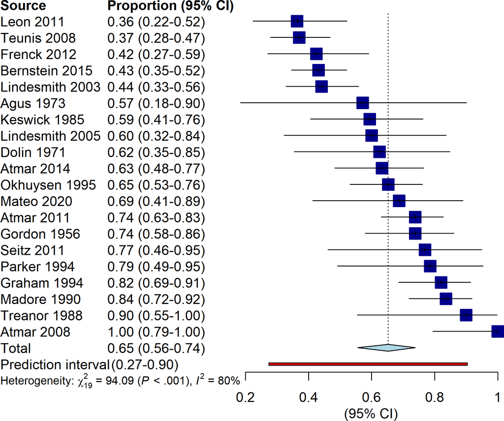

```r
save_base_plot(
  all_studies_meta,
  here::here("figures", "all-studies-forest.png"),
  # I hate this solution but can't figure out a better way
  FUN = function(x, ...) {meta::forest.meta(x, sortvar = TE, ...)},
  fs.hetstat = 10
)

knitr::include_graphics(here::here("figures", "all-studies-forest.png"))
```

```r
# Save sorted by year as well
save_base_plot(
  all_studies_meta,
  here::here("figures", "all-studies-forest-yr.png"),
  # I hate this solution but can't figure out a better way
  FUN = function(x, ...) {meta::forest.meta(x, sortvar = year, ...)},
  fs.hetstat = 10
)
```

Let’s make the drapery plot also which could be fun.

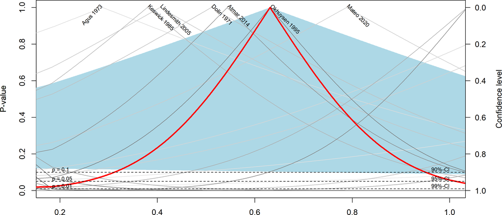

```r
save_base_plot(
  all_studies_meta,
  here::here("figures", "all-studies-drapery.png"),
  FUN = meta::drapery,
  labels = "studlab",
  type = "pval",
  legend = FALSE,
  fixed = FALSE
)
knitr::include_graphics(here::here("figures", "all-studies-drapery.png"))
```

Huh. maybe not so fun. Let’s talk about the forest plot again.

We can see that there is quite a lot of heterogeneity among the different studies. Obviously we should use the random effects model here, but even that has $I^2 = 80\%$. However, we can see that some studies are more similar than others, so my next step will be doing various types of heterogeneity analysis to see if we can find any meaningful subgroups. I’ll also do manual subgroup analysis later to see if that matches with what we find from the influence analysis.

First, let’s do simple outlier detection: we’ll remove any studies whose CIs don’t overlap with the pooled (random effects) estimate. This is likely not a good way to draw conclusions, but it can help us get a handle on what causes the most heterogeneity.

```r
# simple outlier detection
simple_outliers <- find.outliers(all_studies_meta)
so_meta <- simple_outliers$m.random %>%
  update.meta(exclude = c(2, which(simple_outliers$m.random$exclude)))

save_base_plot(
  so_meta,
  here::here("figures", "all-studies-SO.png"),
  FUN = function(x, ...) {meta::forest.meta(x, sortvar = TE, ...)},
  fs.hetstat = 10
)
so_meta
```

```
## Review:     Proportion of challenge participants with confirmed infection
##
## Number of studies combined: k = 15
## Number of observations: o = 898
## Number of events: e = 526
##
##                      proportion          95%-CI
## Random effects model     0.6982 (0.6247-0.7628)
## Prediction interval             (0.4719-0.8569)
##
## Quantifying heterogeneity:
##  tau^2 = 0.1703; tau = 0.4127; I^2 = 52% (14%-74%); H = 1.45 (1.08-1.94)
##
## Test of heterogeneity:
##      Q d.f. p-value             Test
##  29.36   14    .009        Wald-type
##  31.81   14    .004 Likelihood-Ratio
##
## Details on meta-analytical method:
## - Random intercept logistic regression model
## - Maximum-likelihood estimator for tau^2
## - Hartung-Knapp adjustment for random effects model
## - Logit transformation
## - Continuity correction of 0.5 in studies with zero cell frequencies
##   (only used to calculate individual study results)
```

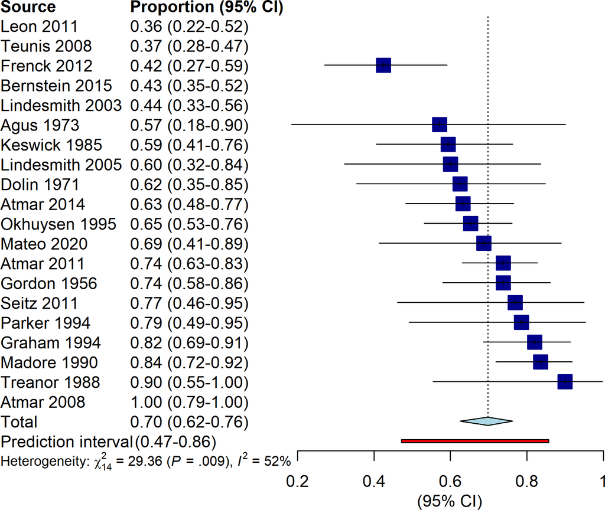

```r
knitr::include_graphics(here::here("figures", "all-studies-SO.png"))
```

The studies chosen as outliers (using the random effects model) are: Bernstein 2015, Leon 2011, Lindesmith 2003, Teunis 2008. (There isn’t a conjunction here because I automatically collapsed that list as inline R code, sorry.) Those all appear to be more modern studies, we’ll look at what they might have in common in a bit.

Next let’s do a leave-one-out (LOO) analysis.

```r
# LOO analysis
# All plots are created at the same time so I have to keep repeating code
# to individually change the text sizes (rolling eyes emoji)
all_studies_inf <- dmetar::InfluenceAnalysis(all_studies_meta, random = TRUE,
                                             text.scale = 1.25)
```

```
## [===========================================================================] DONE
```

```r
save_base_plot(
  all_studies_inf,
  here::here("figures", "all-studies-loo-es.png"),
  plot,
  which = "es"
)
save_base_plot(
  all_studies_inf,
  here::here("figures", "all-studies-loo-i2.png"),
  plot,
  which = "I2"
)

all_studies_inf <- dmetar::InfluenceAnalysis(all_studies_meta, random = TRUE,
                                             text.scale = 2.5)
```

```
## [===========================================================================] DONE
```

```r
save_base_plot(
  all_studies_inf,
  here::here("figures", "all-studies-loo-baujat.png"),
  plot,
  which = "baujat"
)
all_studies_inf <- dmetar::InfluenceAnalysis(all_studies_meta, random = TRUE,
                                             text.scale = 300)
```

```
## [===========================================================================] DONE
```

```r
save_base_plot(
  all_studies_inf,
  here::here("figures", "all-studies-loo-influence.png"),
  plot,
  which = "influence",
  w = 2000,
  h = 2500
)
```

Remove studies and get forest plot.

```r
meta_LOO <- update.meta(all_studies_meta, exclude = c(5, 15, 19))
save_base_plot(
  meta_LOO,
  here::here("figures", "loo-forest.png"),
  # I hate this solution but can't figure out a better way
  FUN = function(x, ...) {meta::forest.meta(x, sortvar = TE, ...)},
  fs.hetstat = 10
)
```

Good thing we can do something similar. Next I’ll do a GOSH analysis, but I don’t remember what that stands for. We’ll fit 1,000,000 models with randomly chosen predictor subsets and plot the heterogeneity vs. effect size measurement. Due to support issues with the `metafor` package, this model is fitted using a different algorithm but the trends should be similar.

```r
# GOSH plot
## Convert to metafor
all_studies_mf <-
  metafor::rma(
    xi = all_studies_meta$event,
    ni = all_studies_meta$n,
    method = all_studies_meta$method.tau,
    slab = all_studies_meta$studlab,
    measure = "PLO"
  )

# Not exactly the same but very close and I can't figure out what's wrong.
# Should be fine to try GOSH anyways though.

# GOSH analysis
all_studies_gosh <- gosh(all_studies_mf,
                         parallel = "snow",
                         ncpus = 30)
```

```
## Fitting 1e+06 models (based on random subsets).
```

Let’s show the GOSH plot.

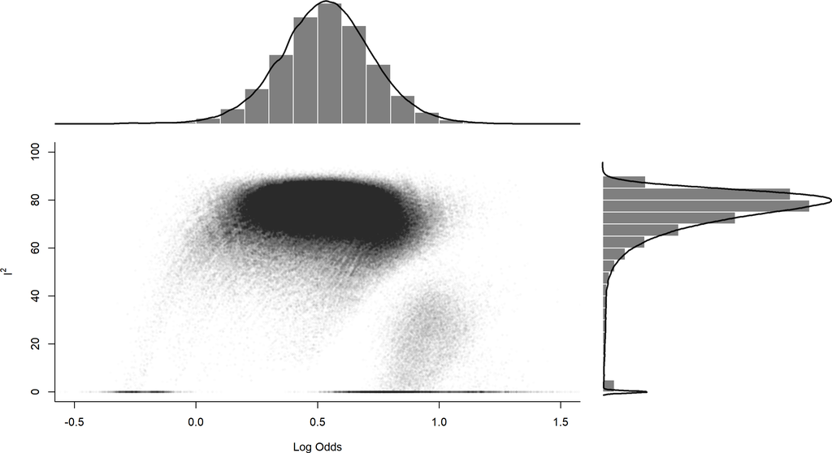

```r
save_base_plot(
  all_studies_gosh,
  here::here("figures", "all-studies-GOSH.png"),
  FUN = plot,
  alpha = 0.01,
  xlim = c(-0.5, 1.5),
  ylim = c(0,100)
)
knitr::include_graphics(here::here("figures", "all-studies-GOSH.png"))
```

There are a few interesting patterns in the GOSH analysis. Most notably, the streak of subsets which appear to have heterogeneity 0.

```r
# Gosh diagnostics
all_studies_gosh_diag <- gosh.diagnostics(
  all_studies_gosh,
  km.params = list(centers = 2),
  db.params = list(MinPts = 15, eps = 0.25)
)
```

```
##
##  Perform Clustering...
##  |==========================================================================================| DONE
```

```r
save_base_plot(
  all_studies_gosh_diag,
  here::here("figures", "gosh-diag-outliers.png"),
  FUN = function(x) {
    with(
      x,
      gridExtra::grid.arrange(
        plot.study5.removed,
        plot.study11.removed,
        plot.study14.removed,
        plot.study19.removed
      )
    )
  }
)

save_base_plot(
  all_studies_gosh_diag,
  here::here("figures", "gosh-diag-clusters.png"),
  FUN = function(x) {
    with(
      x,
      gridExtra::grid.arrange(
        km.plot,
        db.plot,
        gmm.plot
      )
    )
  },
   w = 4000, h = 4500
)
```

```r
meta_GOSH <- update.meta(all_studies_meta, exclude = c(5, 11, 14, 19))
save_base_plot(
  meta_GOSH,
  here::here("figures", "gosh-forest.png"),
  # I hate this solution but can't figure out a better way
  FUN = function(x, ...) {meta::forest.meta(x, sortvar = TE, ...)},
  fs.hetstat = 10
)
```

```r
no_outliers <- update.meta(all_studies_meta, exclude = c(5, 11, 14, 19))
save_base_plot(
  no_outliers,
  here::here("figures", "all-studies-NO.png"),
  FUN = function(x, ...) {meta::forest.meta(x, sortvar = TE, ...)},
  fs.hetstat = 10
)
no_outliers
```

```
## Review:     Proportion of challenge participants with confirmed infection
##
## Number of studies combined: k = 16
## Number of observations: o = 898
## Number of events: e = 526
##
##                      proportion          95%-CI
## Random effects model     0.6853 (0.5956-0.7631)
## Prediction interval             (0.3819-0.8848)
##
## Quantifying heterogeneity:
##  tau^2 = 0.3115; tau = 0.5581; I^2 = 59% (30%-77%); H = 1.57 (1.19-2.07)
##
## Test of heterogeneity:
##      Q d.f. p-value             Test
##  36.92   15    .001        Wald-type
##  54.04   15  < .001 Likelihood-Ratio
##
## Details on meta-analytical method:
## - Random intercept logistic regression model
## - Maximum-likelihood estimator for tau^2
## - Hartung-Knapp adjustment for random effects model
## - Logit transformation
## - Continuity correction of 0.5 in studies with zero cell frequencies
##   (only used to calculate individual study results)
```

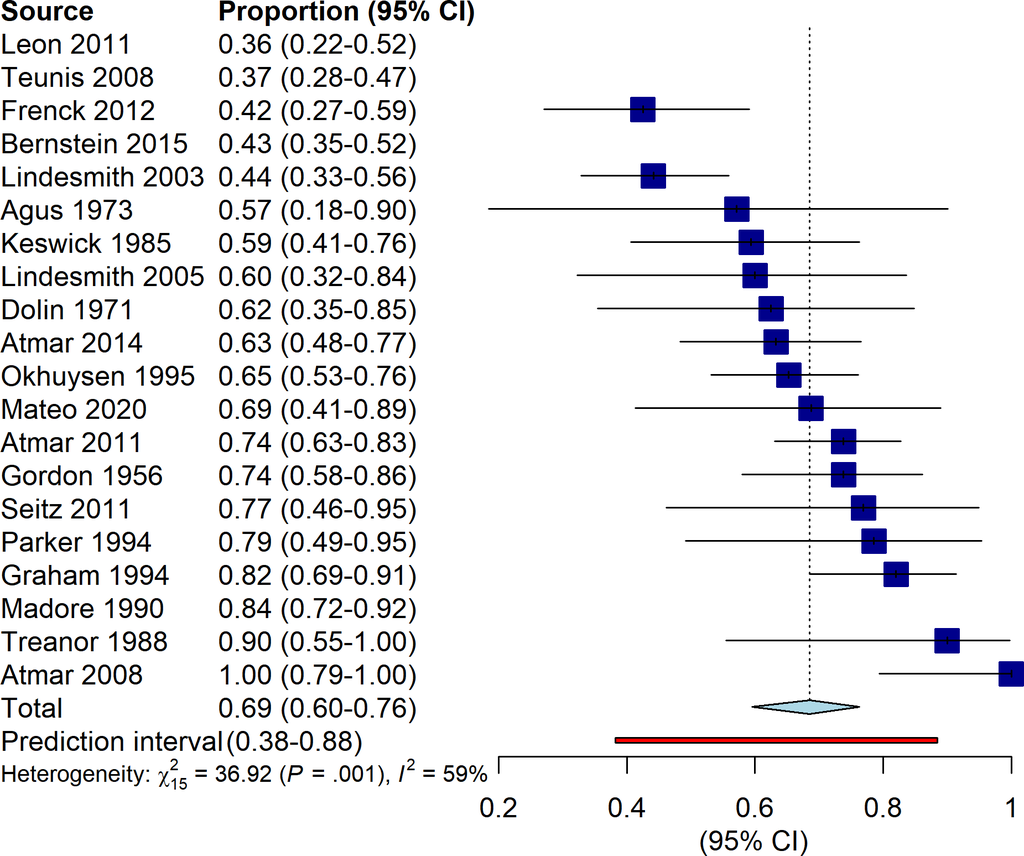

```r
knitr::include_graphics(here::here("figures", "all-studies-NO.png"))
```

This decreases the heterogeneity, but there seems to be no real pattern for why these studies are outliers.

Subgroup analysis for FUT2+ only vs. uncontrolled.

```r
fut2_df <- dat %>%
  filter(secretor_status != "FUT2-") %>%
  group_by(study, FUT2 = secretor_status) %>%
  summarize(
    across(starts_with("number"), sum),
    year = min(year_published),
    .groups = "drop"
  )

fut2_meta <- fut2_df %>%
  meta::metaprop(
    event = number_infected,
    n = number_challenged,
    studlab = study,
    data = .,
    method = "GLMM",
    sm = "PLOGIT",
    method.tau = "ML",
    fixed = FALSE,
    hakn = TRUE,
    prediction = TRUE,
    title = "Proportion infected by FUT2 control",
    subgroup = FUT2
  )

save_base_plot(
  fut2_meta,
  here::here("figures", "fut2-forest.png"),
  FUN = function(x, ...) {meta::forest.meta(x, sortvar = TE, ...)},
  h = 2400,
  fs.hetstat = 10
)
```

Subgroup analysis for genotype.

```r
gt_df <- dat %>%
  group_by(study, genotype = genogroup) %>%
  summarize(
    across(starts_with("number"), sum),
    year = min(year_published),
    .groups = "drop"
  )

gt_meta <- gt_df %>%
  meta::metaprop(
    event = number_infected,
    n = number_challenged,
    studlab = study,
    data = .,
    method = "GLMM",
    sm = "PLOGIT",
    method.tau = "ML",
    fixed = FALSE,
    hakn = TRUE,
    prediction = TRUE,
    title = "Proportion infected by inoculum genotype",
    subgroup = genotype
  )

save_base_plot(
  gt_meta,
  here::here("figures", "gt-forest.png"),
  FUN = function(x, ...) {meta::forest.meta(x, sortvar = TE, ...)},
  h = 3200,
  fs.hetstat = 10
)
```

Not enough info, so stratify by genogroup instead.

```r
gg_df <- dat %>%
  mutate(
    genogroup = case_when(
      genogroup == "Unknown" ~ "Unknown",
      startsWith(genogroup, "GI.") ~ "G1",
      startsWith(genogroup, "GII.") ~ "G2",
      TRUE ~ genogroup
    )
  ) %>%
  group_by(study, genogroup) %>%
  summarize(
    across(starts_with("number"), sum),
    year = min(year_published),
    .groups = "drop"
  )

gg_meta <- gg_df %>%
  meta::metaprop(
    event = number_infected,
    n = number_challenged,
    studlab = study,
    data = .,
    fixed = FALSE,
    method = "GLMM",
    sm = "PLOGIT",
    method.tau = "ML",
    hakn = TRUE,
    prediction = TRUE,
    subgroup = genogroup
  )

save_base_plot(
  gg_meta,
  here::here("figures", "gg-forest.png"),
  FUN = function(x, ...) {meta::forest.meta(x, sortvar = TE, ...)},
  h = 2800,
  fs.hetstat = 10
)
```

Risk of bias (low vs med/high).

```r
rob_df <- dat %>%
  mutate(
    RoB = ifelse(risk_of_bias == "H", "High", "Med/Low")
  ) %>%
  group_by(study, RoB) %>%
  summarize(
    across(starts_with("number"), sum),
    year = min(year_published),
    .groups = "drop"
  )

rob_meta <- rob_df %>%
  meta::metaprop(
    event = number_infected,
    n = number_challenged,
    studlab = study,
    data = .,
    fixed = FALSE,
    method = "GLMM",
    sm = "PLOGIT",
    method.tau = "ML",
    hakn = TRUE,
    prediction = TRUE,
    subgroup = RoB
  )

save_base_plot(
  rob_meta,
  here::here("figures", "rob-forest.png"),
  FUN = function(x, ...) {meta::forest.meta(x, sortvar = TE, ...)},
  h = 2800,
  fs.hetstat = 10
)
```

risk of bias plot.

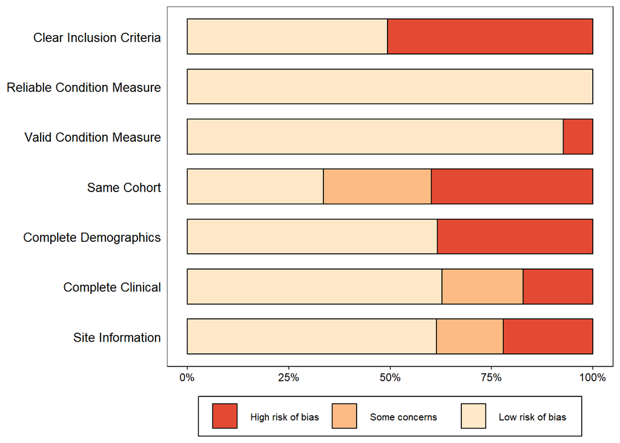

```r
rob_data_orig <- read.csv(here::here("data", "study-quality.csv"))
rob_data <- rob_data_orig %>%
  select(-EndNote.record..) %>%
  mutate(study = paste(First.author, Year.published),
         .after = Year.published, .keep = "unused") %>%
  mutate(across(!study, ~case_when(
    .x %in% c("L", "Y") ~ "Low",
    .x %in% c("M", "U") ~ "Some concerns",
    .x %in% c("H", "N") ~ "High"
  )))
rob_data$W <- (all_studies_df$number_challenged)
rob_summary(rob_data, tool = "ROB1", colour = "colourblind")
```

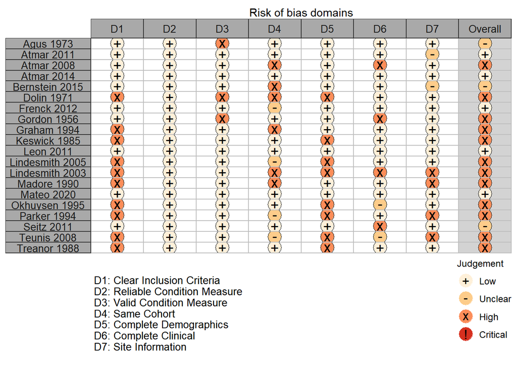

```r
ggsave(here::here("figures", "rob-summary.png"), width = 6.25, height = 3)
rob_traffic_light(rob_data, tool = "ROB1", colour = "colourblind", psize = 6) +
  theme(strip.text.y.left = element_text(size = 10, angle = 0),
        axis.title.y.left = element_blank())
```

```r
ggsave(here::here("figures", "rob-traffic-light.png"), width = 6, height = 8)
```

Cumulative meta analysis based on year of publication.

```r
year_cum <- metacum(all_studies_meta, "random", year)
year_cum
```

```
## Review:     Proportion of challenge participants with confirmed infection
##
## Cumulative meta-analysis (Random effects model)
##
##                                 proportion          95%-CI p-value   tau^2
## Adding Gordon 1956 (k=1)            0.7381 (0.5862-0.8486)
## Adding Dolin 1971 (k=2)             0.7069 (0.0581-0.9895)          0.0000
## Adding Agus 1973 (k=3)              0.6923 (0.4145-0.8773)          0.0000
## Adding Keswick 1985 (k=4)           0.6598 (0.4951-0.7932)          0.0000
## Adding Treanor 1988 (k=5)           0.6822 (0.5468-0.7926)          0.0000
## Adding Madore 1990 (k=6)            0.7303 (0.5919-0.8348)          0.1282
## Adding Graham 1994 (k=7)            0.7500 (0.6388-0.8357)          0.1171
## Adding Parker 1994 (k=8)            0.7537 (0.6569-0.8303)          0.0949
## Adding Okhuysen 1995 (k=9)          0.7359 (0.6482-0.8082)          0.1026
## Adding Lindesmith 2003 (k=10)       0.7029 (0.5876-0.7971)          0.3034
## Adding Lindesmith 2005 (k=11)       0.6952 (0.5887-0.7842)          0.2793
## Adding Atmar 2008 (k=12)            0.7247 (0.6089-0.8165)          0.4242
## Adding Teunis 2008 (k=13)           0.6993 (0.5692-0.8036)          0.6164
## Adding Atmar 2011 (k=14)            0.7010 (0.5847-0.7962)          0.5481
## Adding Leon 2011 (k=15)             0.6804 (0.5596-0.7810)          0.6405
## Adding Seitz 2011 (k=16)            0.6851 (0.5710-0.7805)          0.6113
## Adding Frenck 2012 (k=17)           0.6696 (0.5575-0.7653)          0.6263
## Adding Atmar 2014 (k=18)            0.6658 (0.5619-0.7558)          0.5691
## Adding Bernstein 2015 (k=19)        0.6518 (0.5499-0.7416)          0.5795
## Adding Mateo 2020 (k=20)            0.6528 (0.5559-0.7385)          0.5474
##
## Pooled estimate                     0.6528 (0.5559-0.7385)          0.5474
##                                     tau  I^2
## Adding Gordon 1956 (k=1)
## Adding Dolin 1971 (k=2)          0.0000   0%
## Adding Agus 1973 (k=3)           0.0000   0%
## Adding Keswick 1985 (k=4)        0.0000   0%
## Adding Treanor 1988 (k=5)        0.0000   4%
## Adding Madore 1990 (k=6)         0.3580  46%
## Adding Graham 1994 (k=7)         0.3422  46%
## Adding Parker 1994 (k=8)         0.3080  38%
## Adding Okhuysen 1995 (k=9)       0.3202  41%
## Adding Lindesmith 2003 (k=10)    0.5508  73%
## Adding Lindesmith 2005 (k=11)    0.5285  70%
## Adding Atmar 2008 (k=12)         0.6513  68%
## Adding Teunis 2008 (k=13)        0.7851  80%
## Adding Atmar 2011 (k=14)         0.7403  80%
## Adding Leon 2011 (k=15)          0.8003  82%
## Adding Seitz 2011 (k=16)         0.7818  81%
## Adding Frenck 2012 (k=17)        0.7914  81%
## Adding Atmar 2014 (k=18)         0.7544  79%
## Adding Bernstein 2015 (k=19)     0.7613  81%
## Adding Mateo 2020 (k=20)         0.7398  80%
##
## Pooled estimate                  0.7398  80%
##
## Details on meta-analytical method:GLMM
## - Maximum-likelihood estimator for tau^2
## - Hartung-Knapp adjustment for random effects model
## - Logit transformation
```

```r
save_base_plot(
  year_cum,
  here::here("figures", "cumulative-forest.png"),
  FUN = function(x, ...) {meta::forest.meta(x, ...)},
  h = 2800,
  fs.hetstat = 10
)
```

Meta regression

```r
dat_dose <- dat %>%
  filter(dose_gec != "Unknown") %>%
  mutate(dose = as.numeric(dose_gec)) %>%
  group_by(study, log_dose = log10(dose)) %>%
  summarize(
    across(starts_with("number"), sum),
    year = min(year_published),
    .groups = "drop"
  )

dat_dose_es <-
  escalc(
    measure = "PLO",
    xi = number_infected,
    ni = number_challenged,
    slab = study,
    data = dat_dose
  )

meta_dose <- dat_dose %>%
  meta::metaprop(
    event = number_infected,
    n = number_challenged,
    studlab = study,
    data = .,
    method = "GLMM",
    sm = "PLOGIT",
    method.tau = "ML",
    hakn = TRUE,
    fixed = FALSE,
    prediction = TRUE,
    title = "Proportion of challenge participants by dose"
  )

dose_reg <- metareg(meta_dose, ~log_dose)

pth <- here::here("figures", "meta-reg.png")
pal <- hcl.colors(n = length(unique(dat_dose_es$study)),
                  palette = "Dark 2")
# Create graphics device
png(file = pth, width = 3200, height = 1800, res = 300)
# Actually generate forest plot
plot(x = dat_dose_es$log_dose,
     y = exp(dat_dose_es$yi) / (1 + exp(dat_dose_es$yi)),
     col = pal[dat_dose_es$study |> as.factor() |> as.integer()],
     xlab = "log dose",
     ylab = "proportion infected")
curve(exp(coef(dose_reg)[[1]] + coef(dose_reg)[[2]] * x) /
        (1+exp(coef(dose_reg)[[1]] + coef(dose_reg)[[2]] * x)),
      from = 0, to = 12, n = 10000, add = TRUE)
# Turn off graphics device (quietly)
zlib::quiet(dev.off())
# Trim whitespace
magick::image_read(pth) |>
  magick::image_trim() |>
  magick::image_write(path = pth)
```

Publication bias

```r
save_base_plot(
  all_studies_meta,
  here::here("figures", "contour-funnel.png"),
  FUN = function(x, ...) {
    funnel(x, fixed = FALSE,
           contour.levels = c(0.9, 0.95, 0.99),
           col.contour = c("gray75", "gray85", "gray95"))
    legend(x = "topright",
           legend = c("p < 0.1", "p < 0.05", "p < 0.01"),
           fill = c("gray75", "gray85", "gray95"))
  },
)
```

```r
peters <- metabias(all_studies_meta, method.bias = "peters")
save_base_plot(
  all_studies_meta,
  here::here("figures", "peters-regression.png"),
  FUN = function(x) {
    with(x, {
      plot(
        x = 1 / all_studies_meta$n,
        y = all_studies_meta$TE,
        cex = 1 / sqrt(1/event + 1/(n - event)),
        xlab = "inverse sample size",
        ylab = "estimated log odds"
      )
      abline(a = peters$estimate["intercept"],
             b = peters$estimate["bias"],
             lty = 2)
    }
    )
  }
)
```